# Covid-19: What does the data look like?

by Madeline Egbert, Shellie Jurchisin, Emily Pollock, Aaron Hanrahan, Nick Cory & Ritvik Maripally

5 May 2021

## **Introduction**

A pandemic is an event in which a disease spreads across several countries and affects a large number of people. For over a year, people from all over the world have experienced the COVID-19 pandemic wreaking havoc in their own countries, affecting the people they love and life as they knew it. It is safe to say that the unprecedented events this virus has brought us all range from mild to catastrophic. We wanted to do our own research to get real answers about the state of the United States in regard to the pandemic. We chose to analyze COVID-19 data to understand more about the administration of vaccines as well as the details regarding cases and deaths. Taken from the CDC’s website, our data provides an integrated view of key data for monitoring the COVID-19 pandemic in the United States and allows for the exploration of standardized data across the country. The website includes maps and charts tracking cases, deaths and trends of COVID-19 in the United States, and is updated weekly. The sectors of data this site includes are: Communities, Vaccinations, Cases & Deaths, Demographic Trends, Health Care Settings, Testing, People at Risk, and Communication Resources. We have chosen to focus closely on the “Vaccinations,” “Cases & Deaths” and “Demographic Trends” data from the dates of April 1st - 7th, 2021.

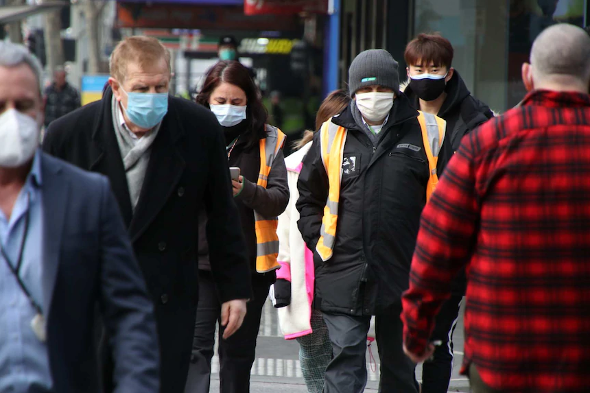

source: https://ab.co/3h3qTlL

## **Questions Raised**

In general, our questions were looking at COVID-19 cases and death data and how it relates to the progress of vaccination administration across the U.S. The specific questions our analysis aimed to answer:

- How does age play a role in the number of cases and deaths?
- What states had the largest amount of cases and deaths over the span of a week?
- Which states have the highest amount of cases overall?
  - Have these states also administered the most vaccinations so far?
    - Which vaccine is the most popular for fully vaccinated people in these states?
- Which vaccine is most popular across the different states?
- How does age play a role in vaccine administration in the midwest?

## **Overview of the Dataset**

GitHub Repository: https://github.com/Aarodynamics3/DS202FinalProject

#### **Obtaining our Data**

Our data came from the covid.cdc.gov/ website and was downloaded on April 7, 2021. The specific datasets that were used in this analysis came from https://covid.cdc.gov/covid-data-tracker/#vaccinations.

Multiple datasets were chosen and implemented in various parts throughout our analysis, those being: deaths by age, cases by age, United States cases and deaths data set, and vaccinations in the United States.

#### **Steps for Data Wrangling and Visualization**

Some of the data sets had to be manually altered to be usable in R because of unnecessary information that was added to the csv files. Furthermore, the column names were not implemented in a very usable format, so they all needed to be changed to be more accessible and easier to use while analyzing the data.

Some generic techniques we also used while cleaning and tidying data throughout the project are removing and reshaping columns, pivoting, and joining.

## **Exploratory Analysis and Answers to Questions Raised**

**How does age play a role in the number of cases and deaths?**

When looking at the analysis there are two main observations that we see in the graph. The first is that a majority of the cases are within the age range of 18-64 years old, but make up a small portion of the deaths. This age group contains 74.2% of all the cases, but only accounts for 19% of the deaths. Of those 19%, 14.6% are in the older part of that grouping being 50-64 years old. This is opposite the opposite of what is seen in the older age groupings of people aged 65+. This age grouping makes up only 14.1% of the total cases, but accounts for 80.9% of the overall deaths. This information is important when understanding the needs for vaccination. We are able to learn about what age groups are most likely to get it, and which it is the most fatal for. Knowing the ages that are the most likely to get it is important because if we focus on vaccinating them we can reduce the rate that it is spreading, and by knowing which age groups that are the most likely to die from covid is important so that we can vaccinate them to reduce the fatality rate.

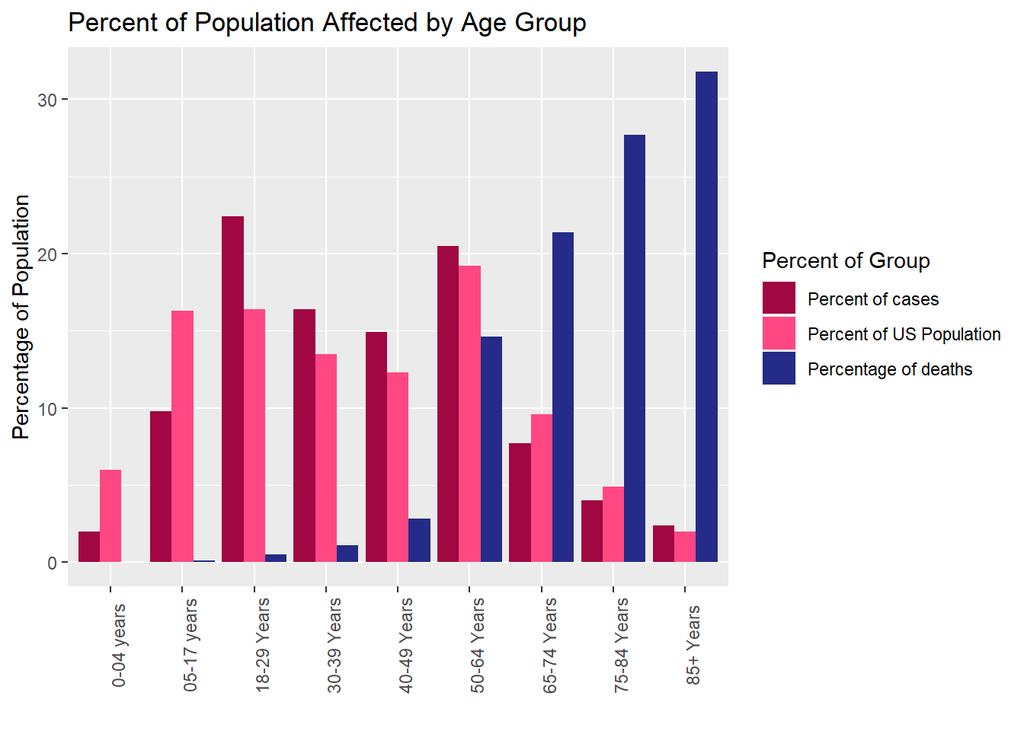

**What states had the largest amount of cases over the span of a week?**

After analyzing the top 10 states with the most cases in the span of a week, we can see that Michigan takes the lead by a fair amount for having the highest count of cases in the last 7 days. Florida follows close behind with between 30,000-40,000 cases in the last 7 days. Overall, the results are the top 10 states being: Michigan (47,036), Florida (36,872), Pennsylvania (30,132), New Jersey (29,753), New York (27,496), Illinois (19,147), Texas (18,074), California (17,995), Ohio (13,810), and Massachusetts (13,725). I was shocked to see New York and California farther away from the most cases in the last week because they are such populated states that have had a really hard time controlling Covid within their state. The biggest shock overall was seeing Michigan with the most cases over the span of a week because Michigan doesn’t seem to be a very covid heavy hotspot and I would’ve assumed Michigan to have it under control.

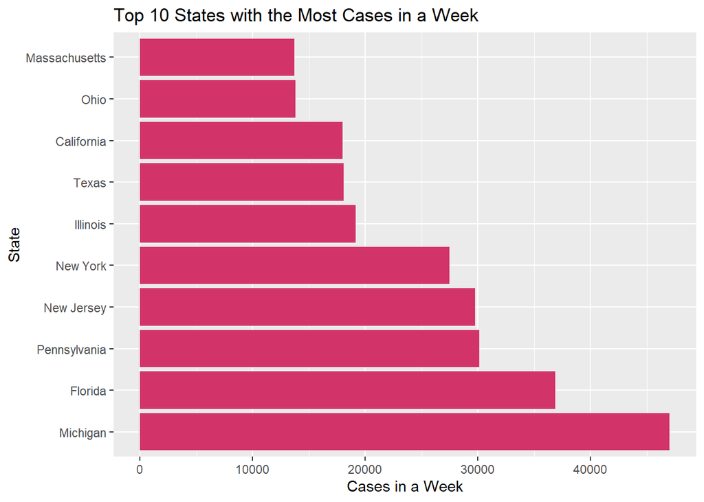

**What states had the largest amount of deaths over the span of a week?**

Now taking a look at the top 10 states that had the most deaths within the span of a week, we can see that California has the highest amount of recorded deaths at 756, a substantially higher amount than the other contenders, especially more than Illinois that takes 10th place with 138. Overall, the state with the largest amounts of deaths is California (756), Texas (580), Florida (463), Georgia (250), New Jersey (245), Massachusetts (191), Pennsylvania(185), New York (169), Virginia (159), and Illinois (138).

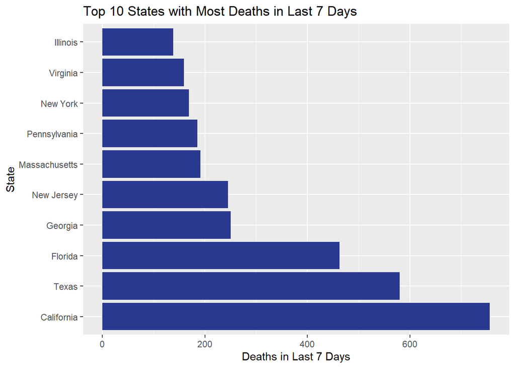

Some correlation that I saw between the results obtained were that the top 5 most populated, something that we discovered in our research, of California, Florida, Texas, New York, and Pennsylvania all showed up amongst the top 10 states with the most deaths. This makes sense mainly due to the correlation that there would presumably be more deaths in heavily populated states. Something that really stood out was the fact that there isn’t too much of a difference between the deaths in California and Illinois. Even though on the bar chart presented it looks like there is a fairly drastic difference, the real difference is only 618 deaths. Based on this discovery, our group could conclude that the spike in Covid19 is slowly but surely mellowing out compared to its severity back in 2020. Tracking and being aware of this data is extremely important in order to detect where outbreaks are occurring, and determine whether public health measures are working

**Which states have the highest amount of cases overall?**

After sorting the COVID case data by the top five states with the highest total cases, we found that California, Texas, Florida, Illinois and Georgia have had the highest total cases over the course of the pandemic so far. All of these states have case totals over one million, but California comes out on top with a whopping 3,582,463 cases. It is no surprise that the states with the highest cases are also in the top 10 for the most populous states in the U.S. What was interesting to find was that New York and Pennsylvania, which make up two of the top five populous states with California, Texas and Florida, did not show up as states with the some of the highest total cases. New York City was hit very hard by the pandemic early on, but according to a Healthline article from this past July, the city was able to regain control over the rising cases by enforcing strict lockdowns and having strong leadership in action. While it is clear that population has played a big role in the spread of the virus, it is also clear that the way each state addressed the pandemic had an effect on their case totals.

```
## # A tibble: 6 x 2
##   State                    `Total Cases`
##   <chr>                            <dbl>
## 1 California                     3582463
## 2 Florida                        2046280
## 3 Georgia                        1065197
## 4 Illinois                       1258736
## 5 Texas                          2794483
## 6 United States of America      30596830
```

Next, I looked into the vaccination administration for the states with the highest number of COVID cases. I first filtered the vaccination data set to find which states were in the top five for vaccine administration. Then, I made a bar chart to visualize the number of vaccinations administered for all the U.S. states to make comparisons.

```
## # A tibble: 5 x 2
##   State        total.Doses.Administered
##   <chr>                           <dbl>
## 1 California                   20485651
## 2 Florida                      10645680
## 3 New York                     10761342
## 4 Pennsylvania                  6802632
## 5 Texas                        13297711
```

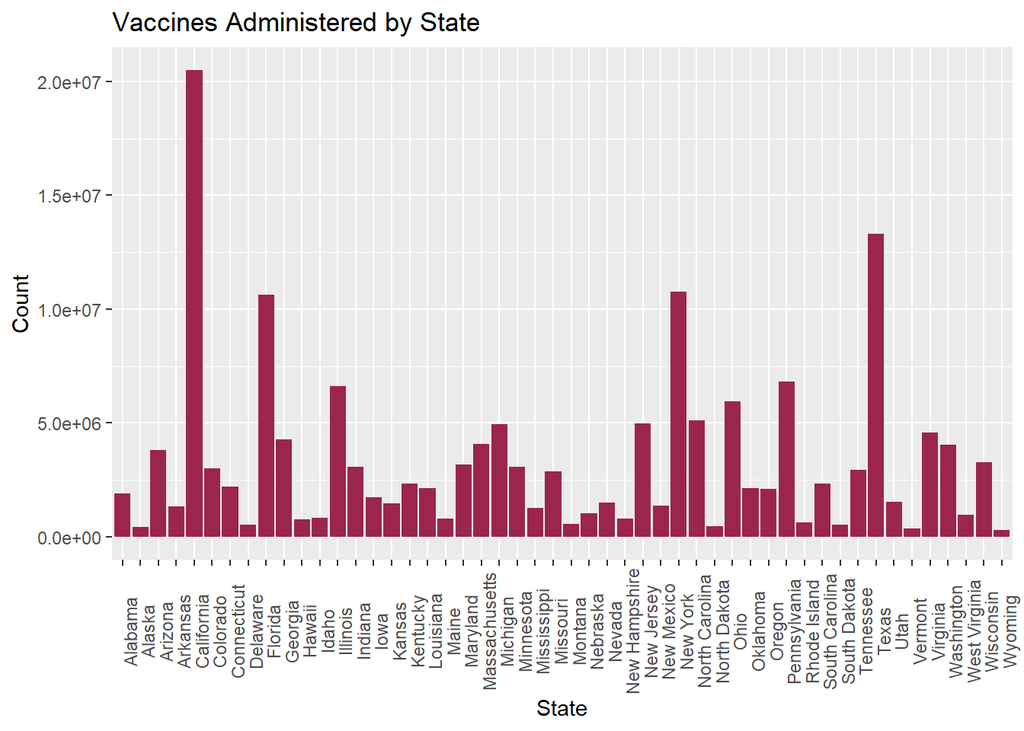

The filtered data set and bar chart show that not all of the top five states for COVID case totals make up the top five states for vaccination administration. Instead, it is the top five populous states (California, Florida, New York, Pennsylvania and Texas) that have administered the most vaccines so far. This makes sense because highly populated states probably have higher concentrations of vaccination sites. Another reason could be that highly populated areas are prioritized for vaccine distribution in order to slow down the spread of the virus where large amounts of people can contract it.

Finally, I looked at which vaccines were the most popular for the top five vaccinated states. I made a faceted bar chart to visualize the amount of vaccines administered for each available type: Pfizer, Moderna and Janssen (the Johnson & Johnson vaccine).

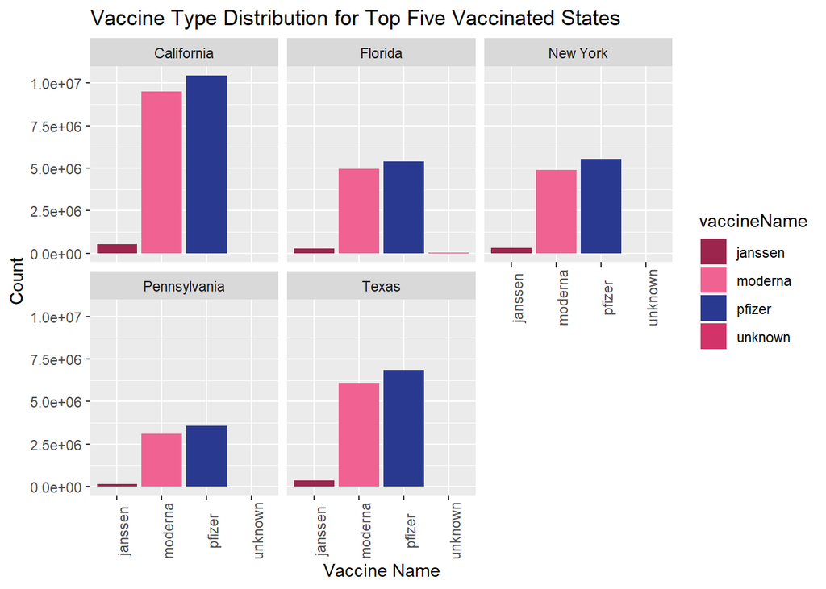

According to the graph, Pfizer is the most administered vaccine type in the top five vaccinated states, with Moderna coming in as a close second. Meanwhile, the Janssen vaccine is rarely getting administered. The differences in administration for each vaccine could simply be attributed to the fact that they were approved at different times in the U.S. The FDA’s website shows that Pfizer was approved on December 11, 2020 and Moderna was approved a week later on December 18. Janssen, however, was not approved until February 27, 2021. After the FDA’s temporary pause on the the use of the Janssen vaccine in late April due to a rare blood clot side effect in young women, it is reasonable to predict that this vaccine will continue to be the least popular in the U.S. Young women may be hesitant to get this vaccine even though the blood clot side effect is very rare. On the other hand, the Janssen vaccine could increase in popularity because it requires only one dose instead of two. This could be a point of analysis for future data projects on the COVID-19 vaccine rollout.

**Which vaccine is most popular across the different states?**

At the time of the data being downloaded, there were predominantly two vaccine companies that were being distributed across the country. The map below shows, per state, which vaccine have more people been fully vaccinated with. The data does include Johnson & Johnson and unknown vaccines, but they are nowhere close to being the most dominant in any state.

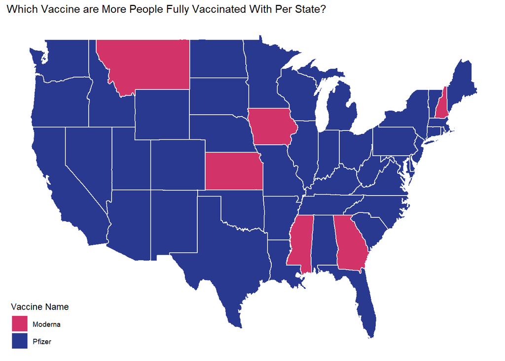

After analyzing the data and looking at the map, it is clear that Pfizer is the more dominant vaccine across the country. However, considering the fact that 2-dose vaccines have about a month gap in between doses as well as Johnson & Johnson more recently being approved, we decided to analyze first doses as well to see if there was any change. The map below shows, per state, which vaccine more people have their first shot administered by.

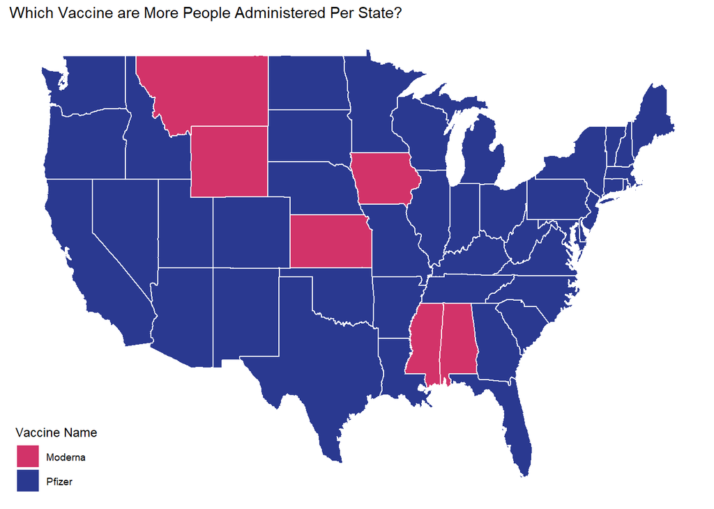

As you can see, there is not much change between people getting their first dose and being fully vaccinated as far as Pfizer being dominant goes. The maps were great to visualize the top, but did not show how close Moderna or Jannsen were behind Pfizer overall. To show this, all of the state values were summed together and converted to percentages in order to show the total across the United States.

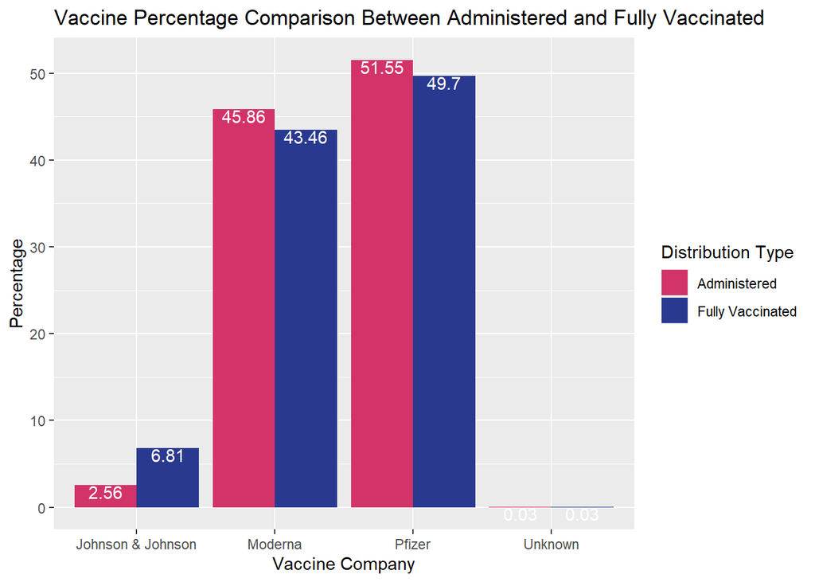

Pfizer leads in both administered and fully vaccinated, but Moderna is very close behind. There is some discrepancy between Jannsen administered and fully vaccinated because it is a single dose vaccine, but it still shows the point of how far behind it is as far as distribution is concerned. Overall the two main companies are pretty equal spread across the country and Johnson & Johnson is likely to gain more of a stake in the future due to its single-shot nature.

**How does age play a role in vaccine administration in the midwest?**

Many states claim that they are prioritizing vaccine rollout to those of age 65 and up as they are the group that faces the most risk while being infected with Covid-19. The map below shows, per state, the percentage of the 65 and older age group that has been vaccinated. The region is limited to the midwest in order to create a more focused viewpoint that is relatable to where we live currently.

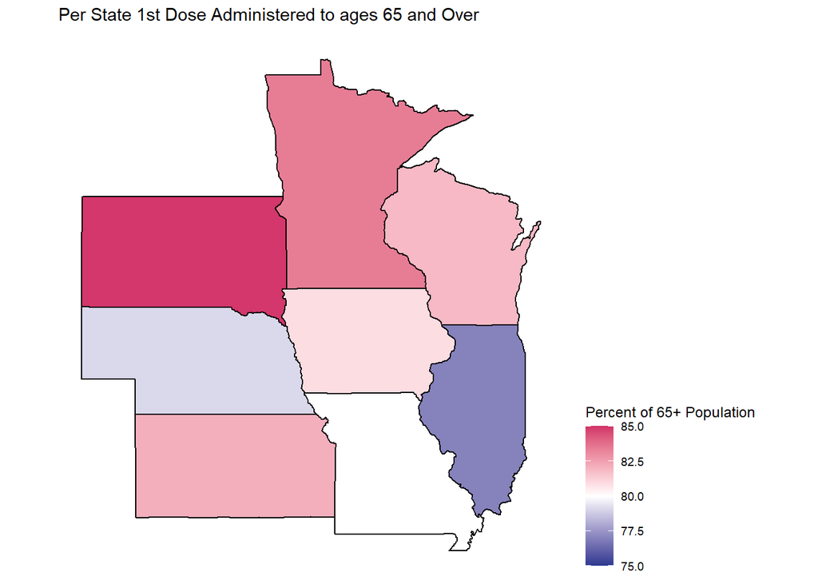

In the midwest, Illinois appears to be the state that has vaccinated the least amount of the 65 and older population (percentage wise) compared to any other state, whereas South Dakota has the most. This is likely due to the smaller population in South Dakota which allows an easier rollout of vaccinations from a logistics standpoint. While the 65 and older group may be the most vulnerable, it is increasingly common that the 65 and under age group are more responsible for the transfer of the virus, so it is important to also look at the vaccine percentage for them as well.

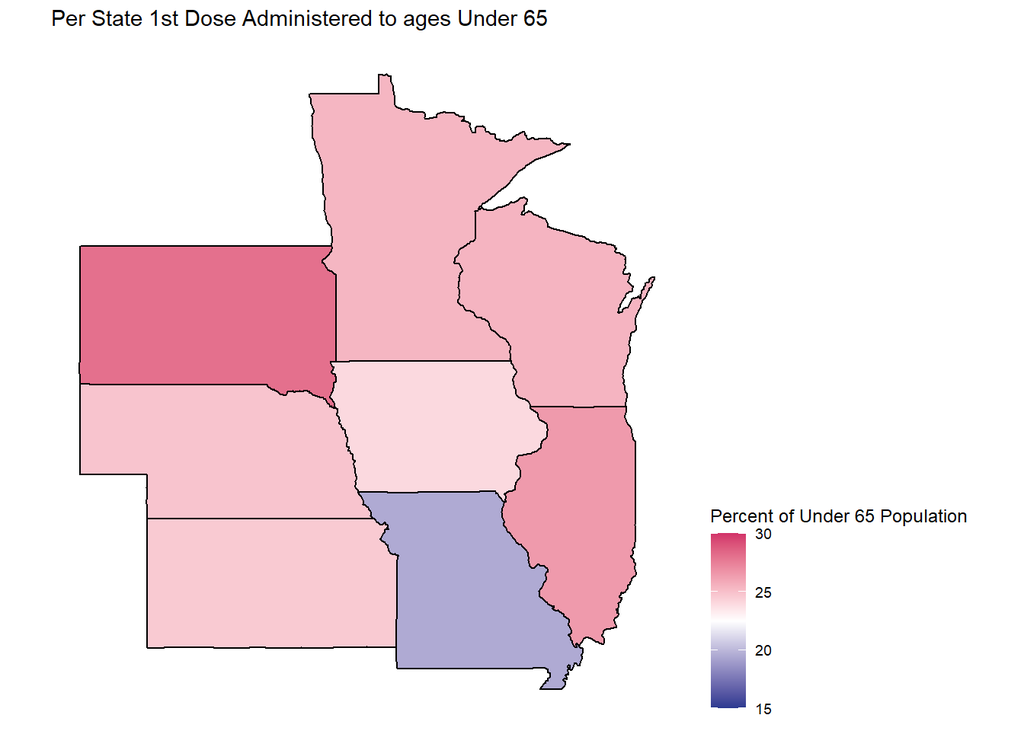

This time Missouri is the state with the lowest percentage of 1st dose administered to the age group of 65 and under. Once again South Dakota leads for likely the same reason as before, with Illinois actually falling close behind. If we had to speculate as to why Illinois may be leading in the younger population is because of its large urban population which is likely younger than its rural population. Urban areas definitely allow for an easier rollout and distribution of the vaccine.

## **Conclusion**

This project gave us the opportunity to only scratch the surface of all you can do with data. Exploring a COVID-19 dataset allowed us to ask questions to which we had not received answers to before. The vaccination data is relatively new and has not been explored much thus far. In uncertain times like today, we don’t always need to rely on the media for snippets of information when we are able to communicate, collaborate and put forth the effort to get the answers ourselves. Overall, our findings can provide U.S. citizens with important information on the status of the pandemic and how the COVID-19 vaccines are being received around the U.S.

## **Contribution Statements**

#### Shellie:

Throughout the duration of this project, I would say that I contributed an even amount compared to the rest of the group. As far as the technical side of things and the overall analysis, we all worked on solving the questions raised, while also coming up with answers. As an individual, I was responsible for answering the question, “What states had the largest amount of deaths over the span of a week?”. I formulated a few visualizations that gave the answer in regard to which states had the most deaths within the span of a week, and then went into detail about what stood out to me in terms of the output produced. In terms of the project presentation, I took on the role of filling out and speaking on the challenges and obstacles our group faced, the techniques used in our analysis, my main findings regarding the question I was responsible for answering, and the conclusion slide. In terms of the report, I believe we all worked equally when it came to transferring our analysis and the technical components of our project, but I played a heavy role in developing the outline and structure of the report, and helped a little more with the story-telling aspect and creative side of things. Overall, I feel as though all members of our group contributed fairly, due to the fact that we communicated efficiently throughout the duration of the project and were able to complete all tasks in a timely manner. My individual analysis can be found on Github (IndividualShellie.Rmd) as .html and .Rmd files.

#### Maddie:

I contributed by answering the question “What states had the highest percent increase in cases over the span of a week?” I chose to look at the ‘Cases in Last 7 Days’ column and ‘State/Territory’ column. I simplified the information into just the top 10 highest case ratings over a week’s time. My findings gave me the top 10 states with the most cases which are: Michigan (47,036), Florida (36,872), Pennsylvania (30,132), New Jersey (29,753), New York (27,496), Illinois (19,147), Texas (18,074), California (17,995), Ohio (13,810), and Massachusetts (13,725). My analysis resulted with the top state being Michigan with 47,036 cases which was one of the most shocking finds throughout our entire groups analysis. My individual analysis can be found on Github (FinalProjectMadelineEgbert.Rmd) as .html and .Rmd files.

#### Emily:

For this project, my contributions included finding the data to use, communicating with my teammates, organizing meetings, doing analysis for one of our five questions and writing up different sections of the presentation and report. In preparation for our project proposal, everyone in the group individually looked for data sets that might be of interest to us for analyze. I thought COVID-19 data, especially vaccination data, would be good to look at due to its relevancy, so I sought out COVID-19 data sets on the CDC’s website. My group members agreed that the data I found would allow us to make an interesting analysis, so we decided to use it for our project. To help organize the different sections of the project and stay on top of due dates, I communicated with my group members weekly. This allowed me to find meeting times that worked for all of us and make sure everyone was on the same page at each stage of the project. For the data analysis, I was in charge of question five, which was a three-part question concerning the top five states for total COVID cases and their vaccination status. For the presentation, I wrote out explanations for my question and wrote the “Questions Raised” slide. I also presented these slides. Overall, I would say my contribution was pretty equal to the contributions of my teammates. My individual analysis can be found under IndividualEmily.Rmd and IndividualEmily.html in our GitHub repository.

#### Aaron:

In addition to my individual analysis, I had set up the repository and performed tidying and refactoring of our data as well. The csv files originally contained some irrelevant information that was messing up them being read in R, so that needed to be removed. All of the column names in our main csv (covid19_vaccinations_in_the_united_states) were long, confusing, and full of spaces which were inconvenient to work with. Many columns also did not come in as numeric values and needed to be converted from character values. My individual analysis was centered around vaccinations, and more specifically which companies were most popular around the United States. For the presentation I also helped find the specific colors of the slides to help match our graphs to the slides for a more professional look. My individual analysis can be found on Github (IndividualAaron.Rmd) as .html and .Rmd files.

#### Nick:

For the project, I contributed by working on answering the question of how age played a role in the number of cases and deaths. To do this, I used the cases_by_age_group, and deaths_by_age_group data sets. I combined these two data sets together and then used the information from them to create a bar chart to easily share the information learned through the analysis. In addition to the work on answering the questions, I also helped out by contributing to the slides in the presentation and presenting on where our data was sourced from, as well as on my analysis. My individual analysis can be found on Github (individualNick.Rmd) as .html and .Rmd files.

## **Works Cited**

Centers for Disease Control and Prevention. (n.d.). CDC COVID Data Tracker. Centers  
for Disease Control and Prevention. https://covid.cdc.gov/covid-data-tracker/#vaccinations.

Commissioner, Office of the. “COVID-19 Vaccines.” U.S. Food and Drug Administration, FDA, 27 Apr. 2021,  
www.fda.gov/emergency-preparedness-and-response/coronavirus  
-disease-2019-covid-19/covid-19-vaccines.

Jamieson, Amy. “How New York City Got Control of COVID-19 — and Where It Goes from Here.” Healthline, Healthline Media,  
20 July 2020, www.healthline.com/health-news  
/how-new-york-city-got-control-of-covid19.